# Tugas 2 IPM

## Library/Packages

```r
library("forecast")
```

```r
library("graphics")
library("TTR")
library("TSA")
```

## Impor Data

```r
library(rio) #install packages jika belum ada
data <- import("https://github.com/aldennabil/MPDW/raw/refs/heads/main/Pertemuan%202/IPM%20Magelang%2012-25.csv")

# menampilkan 5 data pertama
data
```

```
##    Tahun   IPM
## 1   2012 64.18
## 2   2013 64.57
## 3   2014 65.20
## 4   2015 67.13
## 5   2016 67.85
## 6   2017 68.39
## 7   2018 69.11
## 8   2019 69.87
## 9   2020 69.87
## 10  2021 70.12
## 11  2022 70.85
## 12  2023 71.45
## 13  2024 71.99
```

## Eksplorasi Data

```r
summary(data)
```

```
##      Tahun           IPM
##  Min.   :2012   Min.   :64.18
##  1st Qu.:2015   1st Qu.:67.13
##  Median :2018   Median :69.11
##  Mean   :2018   Mean   :68.51
##  3rd Qu.:2021   3rd Qu.:70.12
##  Max.   :2024   Max.   :71.99
```

```r
model = lm(IPM~Tahun, data=data)
summary(model)
```

```
##
## Call:
## lm(formula = IPM ~ Tahun, data = data)
##
## Residuals:
##     Min      1Q  Median      3Q     Max
## -0.7050 -0.4178 -0.2572  0.5747  0.7136
##
## Coefficients:
##               Estimate Std. Error t value Pr(>|t|)
## (Intercept) -1.244e+03  8.442e+01  -14.73 1.38e-08 ***
## Tahun        6.503e-01  4.183e-02   15.54 7.83e-09 ***
## ---
## Signif. codes:  0 '***' 0.001 '**' 0.01 '*' 0.05 '.' 0.1 ' ' 1
##
## Residual standard error: 0.5644 on 11 degrees of freedom
## Multiple R-squared:  0.9565, Adjusted R-squared:  0.9525
## F-statistic: 241.6 on 1 and 11 DF,  p-value: 7.828e-09
```

# Pengujian Asumsi

## Uji Multikolinearitas

```r
# car::vif(model)
```

## Sisaan menyebar normal

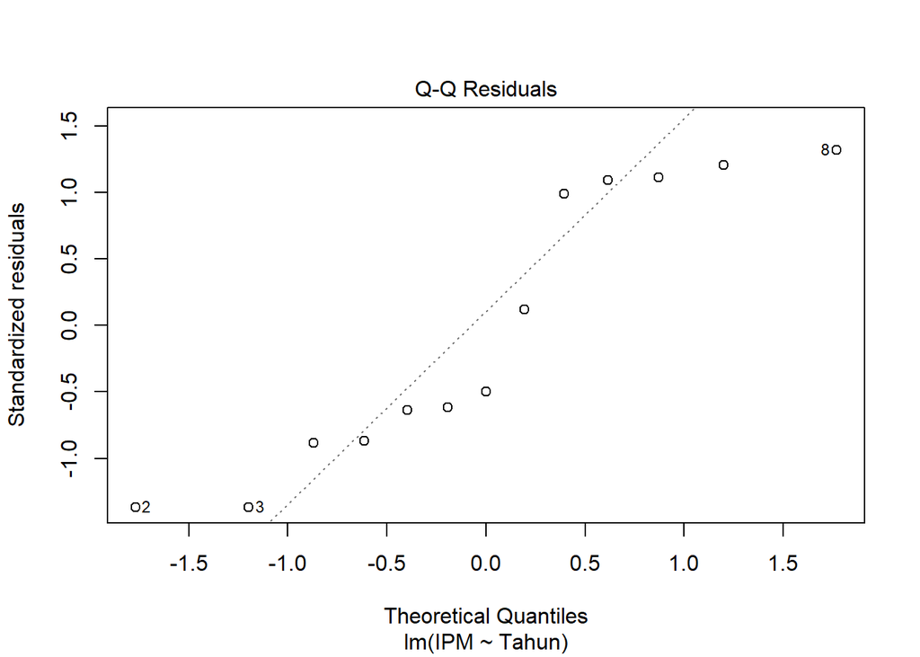

```r
#Dengan eksplorasi
plot(model,2);
```

Hasil QQ-Plot memperlihatkan bahwa titik-titik nya cenderung mengikuti garis kenormalan. Oleh karena itu, dapat disimpulkan bahwa sisaan menyebar normal.

## Nilai harapan sisaan sama dengan nol

```r
# Uji t
t.test(resid(model), mu = 0,)
```

```
##
##  One Sample t-test
##
## data:  resid(model)
## t = -1.4274e-17, df = 12, p-value = 1
## alternative hypothesis: true mean is not equal to 0
## 95 percent confidence interval:
##  -0.3265282  0.3265282
## sample estimates:
##     mean of x
## -2.139214e-18
```

$p-value=1 > 0.1$ (tidak tolak $H_0$) Artinya: Nilai harapan sisaan sama dengan nol

## Ragam sisaan homogen

```r
# Uji Breusch-Pagan
lmtest::bptest(model)
```

```
##
##  studentized Breusch-Pagan test
##
## data:  model
## BP = 4.6313, df = 1, p-value = 0.03139
```

## Antar sisaan tidak saling berkorelasi (tidak terjadi autokorelasi)

```r
# Uji Durbin Watson
library(lmtest)
dwtest(model)
```

```
##
##  Durbin-Watson test
##
## data:  model
## DW = 0.66898, p-value = 0.0003922
## alternative hypothesis: true autocorrelation is greater than 0
```

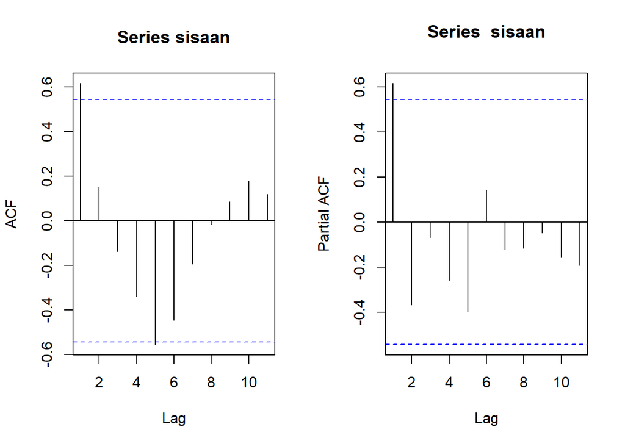

```r
#ACF dan PACF identifikasi autokorelasi
sisaan = model$residuals
par(mfrow = c(1,2))
acf(sisaan)
pacf(sisaan)
```

$p-value=0.00<0.1$ (tolak $H_0$) Artinya: Terjadi autkoorelasi pada sisaan pada taraf `5%`

Selain dari itu, plot ACF juga memperlihatkan adanya autokorelasi. Oleh karena itu, diperlukan penanganan untuk hal tersebut. Terdapat 2 metode yang akan dicobakan: 1. Cochrane-Orcutt 2. Hildreth-Lu

### Metode Cochrane-Orcutt

Penanganan metode Cochrane-Orcutt dapat dilakukan dengan bantuan packages Orcutt pada aplikasi `R` maupun secara manual. Berikut ini ditampilkan cara menggunakan bantuan `library` *packages* `Orcutt`.

```r
#Penanganan Autokorelasi Cochrane-Orcutt dengan Packages Orcutt
library(orcutt)
modelCO<-cochrane.orcutt(model)
modelCO
```

```
## Cochrane-orcutt estimation for first order autocorrelation
##
## Call:
## lm(formula = IPM ~ Tahun, data = data)
##
##  number of interaction: 22
##  rho 0.671767
##
## Durbin-Watson statistic
## (original):    0.66898 , p-value: 3.922e-04
## (transformed): 1.71480 , p-value: 1.861e-01
##
##  coefficients:
##  (Intercept)        Tahun
## -1046.397302     0.552621
```

Selanjutnya akan dilakukan penghitungan secara manual

```r
#Rho optimum
rho<- modelCO$rho
rho
```

```
## [1] 0.6717672
```

Selanjutnya akan dilakukan transformasi secara manual dengan syntax berikut ini.

```r
#Transformasi Manual
#tanpa data pertama - tanpa data terakhir
IPM.trans <- data$IPM[-1]-data$IPM[-12]*rho
Tahun.trans <- data$Tahun[-1]-data$Tahun[-12]*rho

#Membentuk model dengan peubah yang sudah ditransformasi
modelCOmanual<- lm(IPM.trans~Tahun.trans)
summary(modelCOmanual)
```

```
##
## Call:
## lm(formula = IPM.trans ~ Tahun.trans)
##
## Residuals:
##      Min       1Q   Median       3Q      Max
## -0.58316 -0.33168  0.01695  0.18009  0.92682
##
## Coefficients:
##              Estimate Std. Error t value Pr(>|t|)
## (Intercept) -345.5206    76.4871  -4.517 0.001113 **
## Tahun.trans    0.5557     0.1153   4.818 0.000704 ***
## ---
## Signif. codes:  0 '***' 0.001 '**' 0.01 '*' 0.05 '.' 0.1 ' ' 1
##
## Residual standard error: 0.4221 on 10 degrees of freedom
## Multiple R-squared:  0.6989, Adjusted R-squared:  0.6688
## F-statistic: 23.22 on 1 and 10 DF,  p-value: 0.0007041
```

```r
#Mencari Penduga Koefisien Regresi setelah Transformasi ke Persamaan Awal
#b0 bintang = menghapus koefisien b1,b2,b3 dari model
b0bintang <- modelCOmanual$coefficients[-c(2,3,4)]
b0 <- b0bintang/(1-rho)

#b1 = menghapus koefisien b0,b2,b3 dari model
b1 <- modelCOmanual$coefficients[-c(1,3,4)]

b0;b1
```

```
## (Intercept)
##   -1052.669
```

```
## Tahun.trans
##   0.5557262
```

Hasil perhitungan secara manual maupun dengan package menghasilkan kesimpulan yang sama.